# STA 380 Part 2 Exercises Juwon Lee, Aakash Talathi, Milan Patel, Teja Sirigina

https://github.com/juwon0502/STA-380-pt-2-Exercises

# Probability Practice

## Part A.

Given information:

- p(random) = 0.3
- p(truthful) = 0.7
- p(yes) = 0.65
- p(no) = 0.35
- p(yes|random) = 0.3 * 0.5 = 0.15
- p(no|random) = 0.3 * 0.5 = 0.15

We want to figure out p(yes|truthful)

- p(yes|truthful) = p(yes and truthful)/p(truthful)
- p(yes) - p(yes and random) = p(yes and truthful)
- 0.65 - 0.15 = 0.5

Plug in:

- p(yes|truthful) = 0.5/0.7

```r
0.5/0.7
```

```
## [1] 0.7142857
```

## Part B.

Given information:

- p(test positive|has disease) = 0.993
- p(test negative | doesn’t have disease) = 0.9999
- p(has disease) = 0.000025

Therefore:

- p(has disease and tests positive) = 0.000025 * 0.993
- p(has disease and tests negative) = 0.000025 * 0.007
- p(does not have disease and tests positive) = 0.999975 * 0.0001
- p(does not have disease and tests negative) = 0.999975 * 0.9999

```r
0.000025 * 0.993
```

```
## [1] 2.4825e-05
```

```r
0.000025 * 0.007
```

```
## [1] 1.75e-07
```

```r
0.999975 * 0.0001
```

```
## [1] 9.99975e-05
```

```r
0.999975 * 0.9999
```

```
## [1] 0.999875
```

We want to figure out p(has disease | tests positive)

- p(has disease | tests positive) = p(has disease and tests positive)/p(tests positive)
- p(tests positive) = p(does not have disease and tests positive) + p(has disease and tests positive)

  = 0.000024825 + 0.000099975 = 0.0001248

Therefore:

- p(has disease | tests positive) = p(has disease and tests positive)/p(tests positive) = 0.000024825 / 0.0001248 = 0.1989

# Wrangling the Billboard Top 100

```r
library(readr)
billboard <- read_csv("billboard.csv")
```

```
## * `` -> ...1
```

```r
head(billboard,10)
```

| ...1 | url | week_id | week_position | song | performer | song_id | instance | previous_week_position | peak_position | weeks_on_chart | year | week |
| --- | --- | --- | --- | --- | --- | --- | --- | --- | --- | --- | --- | --- |
| 1 | http://www.billboard.com/charts/hot-100/1965-07-17 | 7/17/1965 | 34 | Don't Just Stand There | Patty Duke | Don't Just Stand TherePatty Duke | 1 | 45 | 34 | 4 | 1965 | 29 |
| 2 | http://www.billboard.com/charts/hot-100/1965-07-24 | 7/24/1965 | 22 | Don't Just Stand There | Patty Duke | Don't Just Stand TherePatty Duke | 1 | 34 | 22 | 5 | 1965 | 30 |
| 3 | http://www.billboard.com/charts/hot-100/1965-07-31 | 7/31/1965 | 14 | Don't Just Stand There | Patty Duke | Don't Just Stand TherePatty Duke | 1 | 22 | 14 | 6 | 1965 | 31 |
| 4 | http://www.billboard.com/charts/hot-100/1965-08-07 | 8/7/1965 | 10 | Don't Just Stand There | Patty Duke | Don't Just Stand TherePatty Duke | 1 | 14 | 10 | 7 | 1965 | 32 |
| 5 | http://www.billboard.com/charts/hot-100/1965-08-14 | 8/14/1965 | 8 | Don't Just Stand There | Patty Duke | Don't Just Stand TherePatty Duke | 1 | 10 | 8 | 8 | 1965 | 33 |
| 6 | http://www.billboard.com/charts/hot-100/1965-08-21 | 8/21/1965 | 8 | Don't Just Stand There | Patty Duke | Don't Just Stand TherePatty Duke | 1 | 8 | 8 | 9 | 1965 | 34 |
| 7 | http://www.billboard.com/charts/hot-100/1965-08-28 | 8/28/1965 | 14 | Don't Just Stand There | Patty Duke | Don't Just Stand TherePatty Duke | 1 | 8 | 8 | 10 | 1965 | 35 |
| 8 | http://www.billboard.com/charts/hot-100/1965-09-04 | 9/4/1965 | 36 | Don't Just Stand There | Patty Duke | Don't Just Stand TherePatty Duke | 1 | 14 | 8 | 11 | 1965 | 36 |
| 9 | http://www.billboard.com/charts/hot-100/1997-04-19 | 4/19/1997 | 97 | Don't Keep Wasting My Time | Teddy Pendergrass | Don't Keep Wasting My TimeTeddy Pendergrass | 1 | NA | 97 | 1 | 1997 | 16 |
| 10 | http://www.billboard.com/charts/hot-100/1997-04-26 | 4/26/1997 | 90 | Don't Keep Wasting My Time | Teddy Pendergrass | Don't Keep Wasting My TimeTeddy Pendergrass | 1 | 97 | 90 | 2 | 1997 | 17 |

## Part A.

```r
library(tidyverse)
billboard %>% group_by(performer, song) %>% summarize(count = n()) %>%
  arrange(-count) %>% head(10)
```

| performer | song | count |
| --- | --- | --- |
| Imagine Dragons | Radioactive | 87 |
| AWOLNATION | Sail | 79 |
| Jason Mraz | I'm Yours | 76 |
| The Weeknd | Blinding Lights | 76 |
| LeAnn Rimes | How Do I Live | 69 |
| LMFAO Featuring Lauren Bennett & GoonRock | Party Rock Anthem | 68 |
| OneRepublic | Counting Stars | 68 |
| Adele | Rolling In The Deep | 65 |
| Jewel | Foolish Games/You Were Meant For Me | 65 |
| Carrie Underwood | Before He Cheats | 64 |

This table represents the top 10 most popular songs since 1958. The count is the number of weeks the song appeared on the Billboard top 100 list.

## Part B

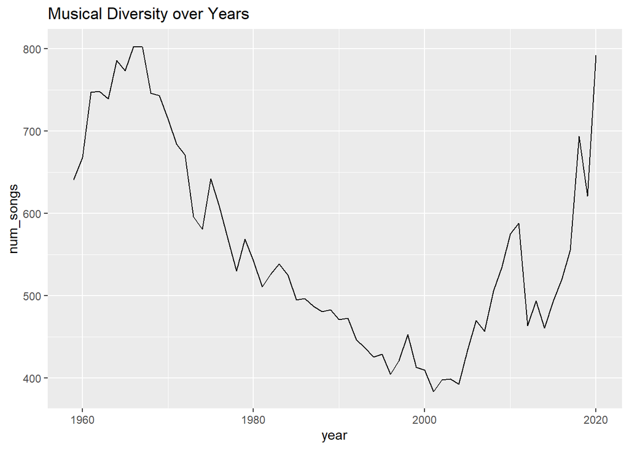

```r
billboard %>% filter(year > 1958 & year < 2021) %>%
  group_by(year) %>%
  summarize(num_songs = n_distinct(song)) %>%
  ggplot() + geom_line(aes(year, num_songs)) +
  ggtitle("Musical Diversity over Years")
```

## Part C

[output not shown]

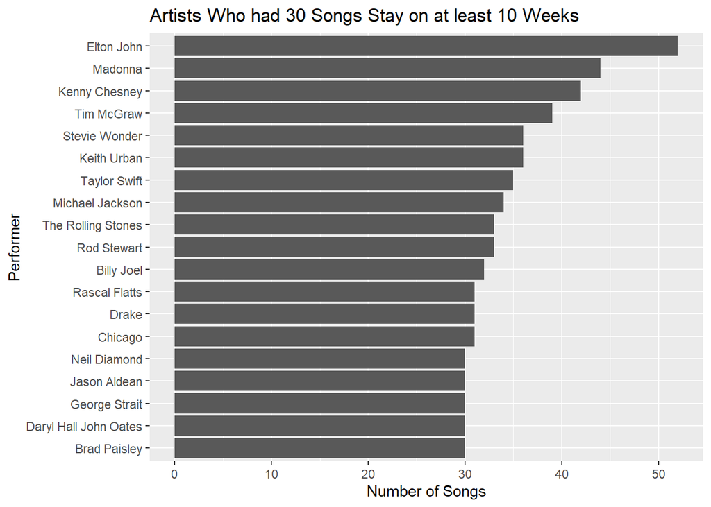

```r
billboard %>% group_by(song, performer) %>%
  summarize(max_weeks = max(weeks_on_chart)) %>%
  filter(max_weeks >= 10) %>%
  group_by(performer) %>% summarize(number_songs_ten_weeks = n()) %>%
  filter(number_songs_ten_weeks >= 30) %>% arrange(-number_songs_ten_weeks) %>%
  ggplot(aes(y = reorder(performer, number_songs_ten_weeks),
             x = number_songs_ten_weeks)) +
  geom_bar(stat = "identity") +
  ylab("Performer") +
  xlab("Number of Songs") +
  ggtitle("Artists Who had 30 Songs Stay on at least 10 Weeks")
```

# Visual story telling part 1: green buildings

```r
library(readr)
greenbuildings <- read_csv("greenbuildings.csv")
greenbuildings %>% head(10)
```

| CS_PropertyID | cluster | size | empl_gr | Rent | leasing_rate | stories | age | renovated | class_a | class_b | LEED | Energystar | green_rating | net | amenities | cd_total_07 | hd_total07 | total_dd_07 | Precipitation | Gas_Costs | Electricity_Costs | cluster_rent |
| --- | --- | --- | --- | --- | --- | --- | --- | --- | --- | --- | --- | --- | --- | --- | --- | --- | --- | --- | --- | --- | --- | --- |
| 379105 | 1 | 260300 | 2.22 | 38.56 | 91.39 | 14 | 16 | 0 | 1 | 0 | 0 | 1 | 1 | 0 | 1 | 4988 | 58 | 5046 | 42.57 | 0.01370000 | 0.02900000 | 36.78 |
| 122151 | 1 | 67861 | 2.22 | 28.57 | 87.14 | 5 | 27 | 0 | 0 | 1 | 0 | 0 | 0 | 0 | 1 | 4988 | 58 | 5046 | 42.57 | 0.01373149 | 0.02904455 | 36.78 |
| 379839 | 1 | 164848 | 2.22 | 33.31 | 88.94 | 13 | 36 | 1 | 0 | 1 | 0 | 0 | 0 | 0 | 1 | 4988 | 58 | 5046 | 42.57 | 0.01373149 | 0.02904455 | 36.78 |
| 94614 | 1 | 93372 | 2.22 | 35.00 | 97.04 | 13 | 46 | 1 | 0 | 1 | 0 | 0 | 0 | 0 | 0 | 4988 | 58 | 5046 | 42.57 | 0.01373149 | 0.02904455 | 36.78 |
| 379285 | 1 | 174307 | 2.22 | 40.69 | 96.58 | 16 | 5 | 0 | 1 | 0 | 0 | 0 | 0 | 0 | 1 | 4988 | 58 | 5046 | 42.57 | 0.01373149 | 0.02904455 | 36.78 |
| 94765 | 1 | 231633 | 2.22 | 43.16 | 92.74 | 14 | 20 | 0 | 1 | 0 | 0 | 0 | 0 | 0 | 1 | 4988 | 58 | 5046 | 42.57 | 0.01373149 | 0.02904455 | 36.78 |
| 236739 | 6 | 210038 | 4.01 | 12.50 | 94.33 | 11 | 38 | 0 | 0 | 1 | 0 | 1 | 1 | 0 | 1 | 2746 | 1670 | 4416 | 25.55 | 0.01010000 | 0.02890000 | 17.50 |
| 234578 | 6 | 225895 | 4.01 | 14.77 | 91.02 | 15 | 24 | 0 | 1 | 0 | 0 | 0 | 0 | 0 | 1 | 2746 | 1670 | 4416 | 25.55 | 0.01011846 | 0.02886870 | 17.50 |
| 42087 | 6 | 912011 | 4.01 | 17.00 | 99.32 | 31 | 34 | 0 | 1 | 0 | 0 | 0 | 0 | 0 | 1 | 2746 | 1670 | 4416 | 25.55 | 0.01011846 | 0.02886870 | 17.50 |
| 233989 | 6 | 518578 | 4.01 | 17.00 | 93.54 | 21 | 36 | 1 | 1 | 0 | 0 | 0 | 0 | 0 | 1 | 2746 | 1670 | 4416 | 25.55 | 0.01011846 | 0.02886870 | 17.50 |

```r
### see how leasing rate correlates with the rest of the variables

lesstenpct=greenbuildings %>% filter(leasing_rate<=10)

cor(lesstenpct[sapply(lesstenpct, is.numeric)],use="complete.obs")[,6]
```

```
##     CS_PropertyID           cluster              size           empl_gr
##       -0.17990645       -0.05930760        0.22640870       -0.02408887
##              Rent      leasing_rate           stories               age
##        0.01306946        1.00000000        0.27228111       -0.07193576
##         renovated           class_a           class_b              LEED
##        0.21374311        0.18560543        0.07772456                NA
##        Energystar      green_rating               net         amenities
##       -0.03289791       -0.03289791       -0.03289791        0.32987392
##       cd_total_07        hd_total07       total_dd_07     Precipitation
##        0.02942398       -0.02906541       -0.01147026       -0.13743538
##         Gas_Costs Electricity_Costs      cluster_rent
##       -0.14631376       -0.06237857       -0.13768930
```

```r
moretenpct=greenbuildings %>% filter(leasing_rate>10)

cor(moretenpct[sapply(moretenpct, is.numeric)],use="complete.obs")[,6]
```

```
##     CS_PropertyID           cluster              size           empl_gr
##      -0.052218347       0.005563464       0.171208141      -0.040143237
##              Rent      leasing_rate           stories               age
##       0.178815521       1.000000000       0.171219443      -0.131089232
##         renovated           class_a           class_b              LEED
##      -0.026941187       0.187001244      -0.063678538       0.015352215
##        Energystar      green_rating               net         amenities
##       0.083125581       0.083723198       0.015524343       0.142021607
##       cd_total_07        hd_total07       total_dd_07     Precipitation
##      -0.025529485       0.007151803      -0.007061384       0.029015296
##         Gas_Costs Electricity_Costs      cluster_rent
##       0.047223786       0.067979687       0.170212818
```

Since the stats guru scrubbed the data clean of buildings with less than 10%, we wanted to see if these data entries were correlated with any of the other variables, and how the correlation differs between the less than 10% full buildings and the more than 10% full buildings. We noticed that in the less than 10% full correlation data, the cluster rent was negatively correlated at -0.137, whereas in the more than 10% correlation data it is positively correlated at 0.17. Other variables of note include amenities and renovated, both of which differ by around 20%. This suggests there may be a structural difference between the two groups and as such we cannot drop the data in which less then 10 percent of the building is being leased.

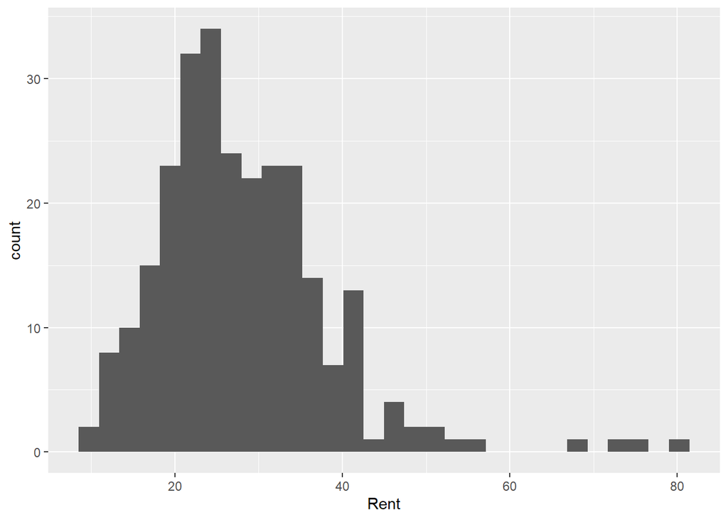

```r
greenbuildings %>% filter(leasing_rate <= 90) %>%
  filter(green_rating == 1) %>%
  ggplot(aes (x = Rent)) + geom_histogram()
```

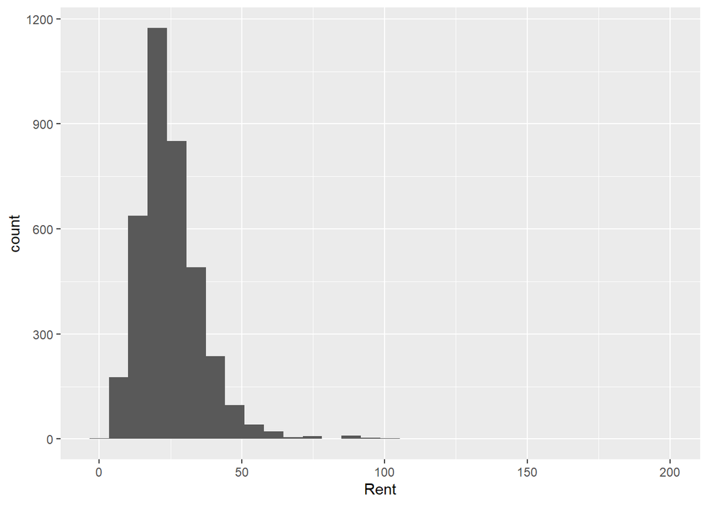

```r
greenbuildings %>% filter(leasing_rate <= 90) %>%
  filter(green_rating == 0) %>%
  ggplot(aes (x = Rent)) + geom_histogram()
```

Just to check the Excel Guru’s reasoning, the distributions were plotted.

We can see if utility costs will differ, which can affect the developer’s decision

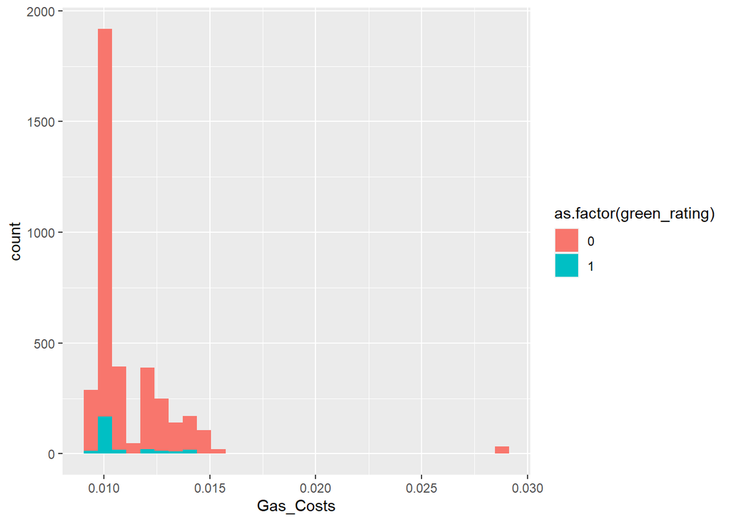

```r
greenbuildings %>% filter(leasing_rate <= 90) %>%
  ggplot(aes (x = Gas_Costs, fill = as.factor(green_rating))) +
  geom_histogram(position = "identity")
```

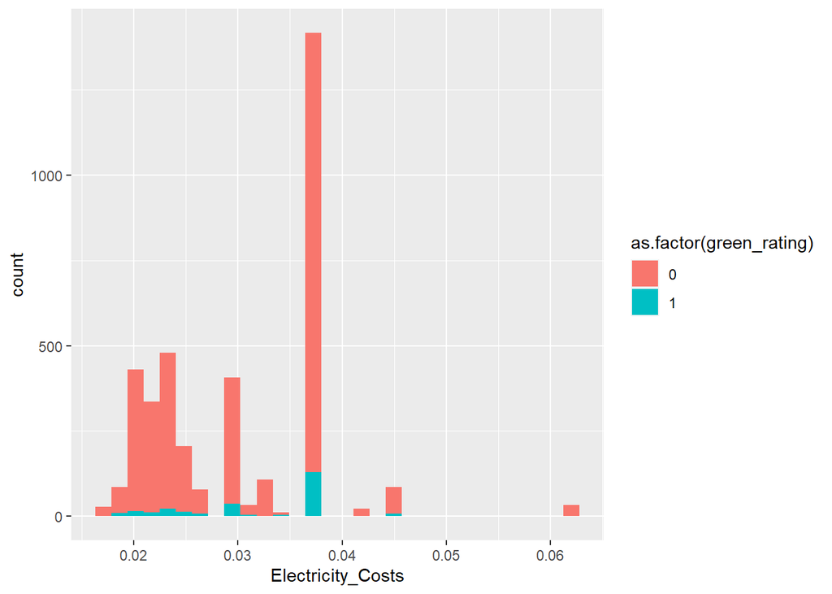

```r
greenbuildings %>% filter(leasing_rate <= 90) %>%
  ggplot(aes (x = Electricity_Costs, fill = as.factor(green_rating))) +
  geom_histogram(position = "identity")
```

These two histograms show us that overall, the cost of electricity and gas is similar for both green buildings and non-green buildings.

The information we can determine from our analysis supports the Excel Guru.

```r
greenbuildings %>% select(Rent, green_rating) %>% group_by(green_rating) %>%
  summarize(x = median(Rent))
```

| green_rating | x |
| --- | --- |
| 0 | 25.0 |
| 1 | 27.6 |

# Visual story telling part 2: Capital Metro data

```r
capmetro <- read_csv("capmetro_UT.csv")
capmetro %>% head(10)
```

| timestamp | boarding | alighting | day_of_week | temperature | hour_of_day | month | weekend |
| --- | --- | --- | --- | --- | --- | --- | --- |
| 2018-09-01 06:00:00 | 0 | 1 | Sat | 74.82 | 6 | Sep | weekend |
| 2018-09-01 06:15:00 | 2 | 1 | Sat | 74.82 | 6 | Sep | weekend |
| 2018-09-01 06:30:00 | 3 | 4 | Sat | 74.82 | 6 | Sep | weekend |
| 2018-09-01 06:45:00 | 3 | 4 | Sat | 74.82 | 6 | Sep | weekend |
| 2018-09-01 07:00:00 | 2 | 4 | Sat | 74.39 | 7 | Sep | weekend |
| 2018-09-01 07:15:00 | 4 | 4 | Sat | 74.39 | 7 | Sep | weekend |
| 2018-09-01 07:30:00 | 3 | 12 | Sat | 74.39 | 7 | Sep | weekend |
| 2018-09-01 07:45:00 | 8 | 4 | Sat | 74.39 | 7 | Sep | weekend |
| 2018-09-01 08:00:00 | 4 | 15 | Sat | 75.72 | 8 | Sep | weekend |
| 2018-09-01 08:15:00 | 7 | 10 | Sat | 75.72 | 8 | Sep | weekend |

How does weather affect the number of students who take the bus?

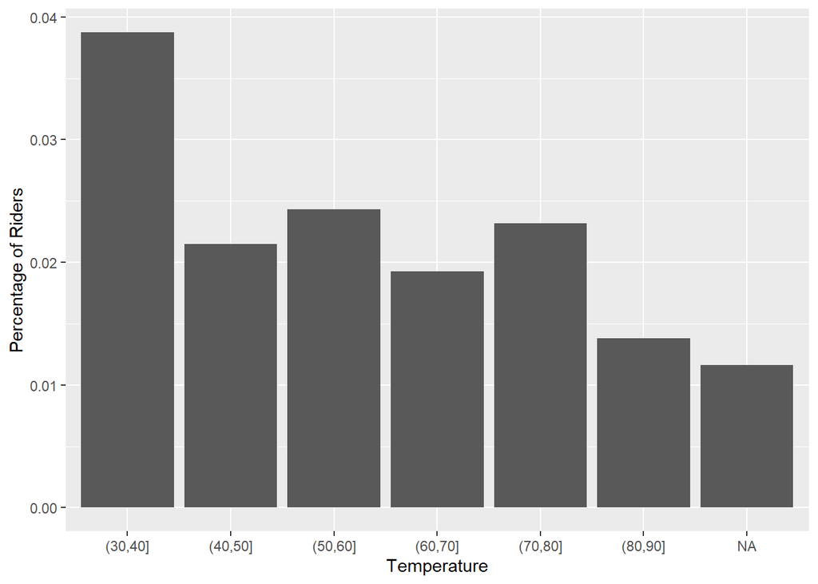

```r
capmetro %>% mutate(temps = cut(temperature, breaks = c(30, 40, 50, 60, 70, 80, 90))) %>% group_by(temps) %>%
  summarize(num_occurance = n(), num_riders = sum(boarding)) %>%
  mutate(riders_per_temp = num_occurance/num_riders) %>%
  ggplot(aes(x = temps, y = riders_per_temp)) + geom_bar(stat = "identity") +
  xlab("Temperature") + ylab("Percentage of Riders")
```

The Y axis was also scaled since there were less occurrences of very hot and very cold days.

What about day of the week?

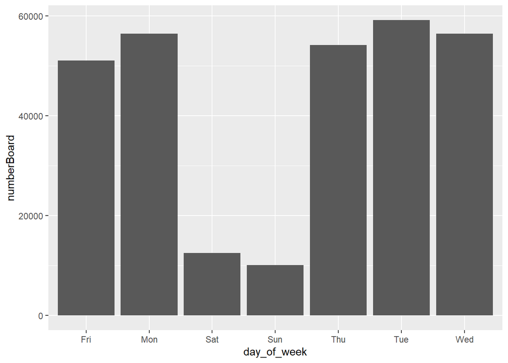

```r
day = capmetro$day_of_week

capmetro %>% group_by(day_of_week) %>% summarize(numberBoard = sum(boarding)) %>% ggplot(aes(x = day_of_week, y = numberBoard)) + geom_bar(stat = "identity")
```

And what about time of day?

```r
model1=lm(data=capmetro,boarding~hour_of_day)
summary(model1)
```

```
##
## Call:
## lm(formula = boarding ~ hour_of_day, data = capmetro)
##
## Residuals:
##    Min     1Q Median     3Q    Max
## -79.46 -30.20 -11.56  23.08 227.17
##
## Coefficients:
##             Estimate Std. Error t value Pr(>|t|)
## (Intercept)   1.2027     1.8532   0.649    0.516
## hour_of_day   3.7266     0.1299  28.686   <2e-16 ***
## ---
## Signif. codes:  0 '***' 0.001 '**' 0.01 '*' 0.05 '.' 0.1 ' ' 1
##
## Residual standard error: 45.7 on 5822 degrees of freedom
## Multiple R-squared:  0.1238, Adjusted R-squared:  0.1237
## F-statistic: 822.9 on 1 and 5822 DF,  p-value: < 2.2e-16
```

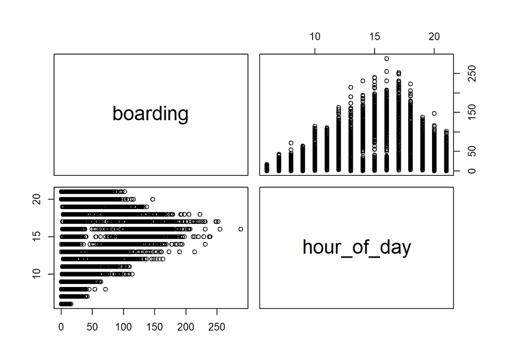

```r
pairs(boarding~hour_of_day, data=capmetro)
```

As we can see from this graph, boarding increases steadily over the course of the day (starting at 6:00 AM), and at around the 16th hour of the day, or 4:00 PM, the boarding peaks and begins to decrease fairly sharply until the end of the day (9:00 PM).

# Portfolio modeling

We decided to use the ETFs SPY, VOO, QQQ, ARKK, and VNQ as they are all different types of ETFs which has SPY, a very safe ETF, and ARKK, a much more risky ETF.

```r
library(mosaic)
library(quantmod)
library(foreach)
myETFs = c("SPY", "VOO", "QQQ", "ARKK", "VNQ")
getSymbols(myETFs, from = "2017-07-31", to = "2022-07-31")
```

```
## [1] "SPY"  "VOO"  "QQQ"  "ARKK" "VNQ"
```

```r
SPYa = adjustOHLC(SPY)
```

```r
QQQa = adjustOHLC(QQQ)
VOOa = adjustOHLC(VOO)
ARKKa = adjustOHLC(ARKK)
VNQa = adjustOHLC(VNQ)
all_returns = cbind(ClCl(SPYa),
                                    ClCl(VOOa),
                                    ClCl(QQQa),
                                    ClCl(VNQa),
                                    ClCl(ARKKa))

head(all_returns)
```

```
##                ClCl.SPYa     ClCl.VOOa    ClCl.QQQa    ClCl.VNQa  ClCl.ARKKa
## 2017-07-31            NA            NA           NA           NA          NA
## 2017-08-01  0.0022288082  0.0022502427  0.002304001  0.004509815 0.002633212
## 2017-08-02  0.0004851811  0.0005723311  0.002716627 -0.009097306 0.003771010
## 2017-08-03 -0.0019398440 -0.0017599173 -0.003890226 -0.002027018 0.007480209
## 2017-08-04  0.0018221452  0.0016748501  0.001813202  0.003345353 0.012152489
## 2017-08-07  0.0018592255  0.0016281352  0.006334870 -0.001071731 0.018749967
```

```r
all_returns = as.matrix(na.omit(all_returns))
```

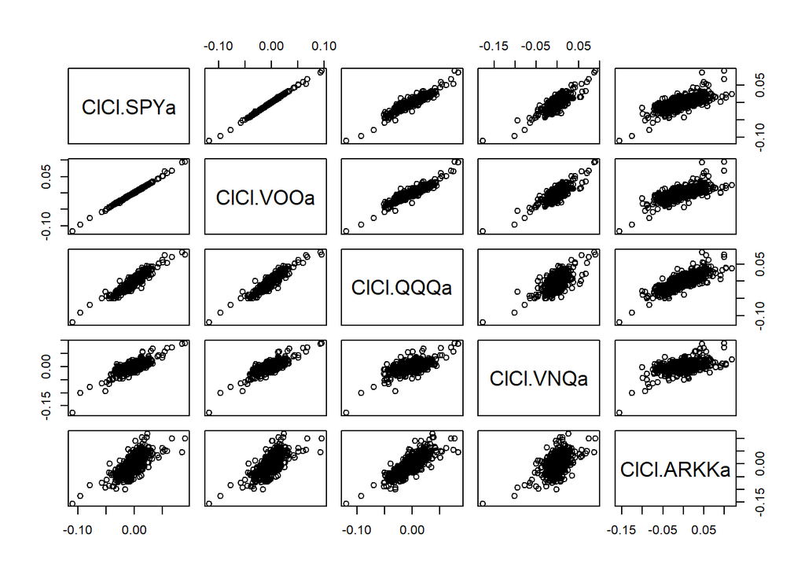

```r
pairs(all_returns)
```

## Low-Risk Model

```r
return.today = resample(all_returns, 1, orig.ids=FALSE)

# Update the value of your holdings
# Assumes an equal allocation to each asset
total_wealth = 100000
my_weights = c(0.8,0.05,0.05, 0.05, 0.05)
holdings = total_wealth*my_weights
holdings = holdings*(1 + return.today)

# Compute your new total wealth
holdings
```

```
##            ClCl.SPYa ClCl.VOOa ClCl.QQQa ClCl.VNQa ClCl.ARKKa
## 2021-01-20   81107.1   5067.94  5116.305  5095.413   5033.532
```

```r
total_wealth = sum(holdings)
total_wealth
```

```
## [1] 101420.3
```

```r
## begin block
total_wealth = 100000
weights = c(0.8, 0.05, 0.05, 0.05, 0.05)
holdings = weights * total_wealth
n_days = 20  # capital T in the notes
wealthtracker = rep(0, n_days) # Set up a placeholder to track total wealth
for(today in 1:n_days) {
    return.today = resample(all_returns, 1, orig.ids=FALSE)  # sampling from R matrix in notes
    holdings = holdings + holdings*return.today
    total_wealth = sum(holdings)
    wealthtracker[today] = total_wealth
}
total_wealth
```

```
## [1] 96009.67
```

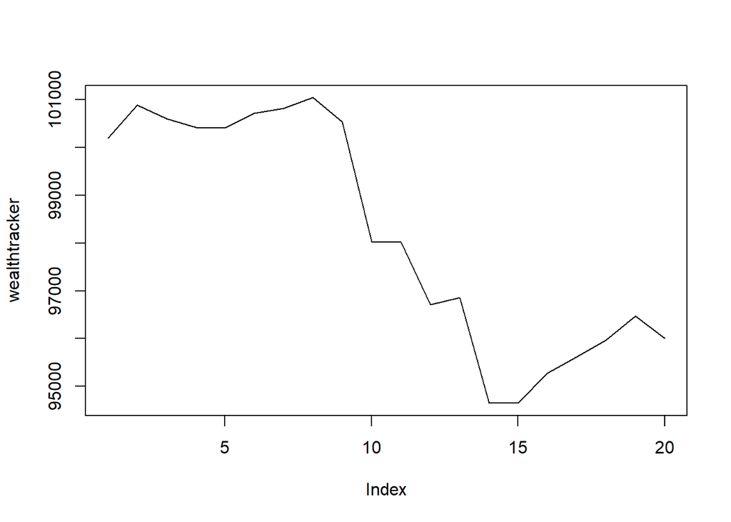

```r
plot(wealthtracker, type='l')
```

```r
## end block
```

```r
initial_wealth = 100000
sim1 = foreach(i=1:5000, .combine='rbind') %do% {
    total_wealth = initial_wealth
    weights = c(0.8, 0.05, 0.05, 0.05, 0.05)
    holdings = weights * total_wealth
    n_days = 20
    wealthtracker = rep(0, n_days)
    for(today in 1:n_days) {
        return.today = resample(all_returns, 1, orig.ids=FALSE)
        holdings = holdings + holdings*return.today
        total_wealth = sum(holdings)
        wealthtracker[today] = total_wealth
    }
    wealthtracker
}

# each row is a simulated trajectory
# each column is a data
head(sim1)
```

```
##               [,1]      [,2]      [,3]     [,4]      [,5]      [,6]      [,7]
## result.1 100240.52 101044.83 100855.74 100597.8 101218.74  99652.62 100878.25
## result.2  96750.69  97597.76  97375.08  98309.6  97919.13  98706.66  98808.82
## result.3  99984.23  99897.69 100725.17 101173.2 101351.71 100699.62 101885.94
## result.4  99004.22 100530.13 101490.96 101210.0 100965.99 101601.78 102365.64
## result.5 101841.36 104608.22 104494.58 104918.1 104999.76 110372.58 111082.97
## result.6  99541.20  99432.89 100006.91 100889.3  99891.18  99118.20  99504.76
##               [,8]      [,9]     [,10]     [,11]     [,12]     [,13]     [,14]
## result.1 102843.60 105407.39 106543.86 105876.49 105203.12 105492.25 106471.38
## result.2  98824.71  99726.38  93903.51  95252.36  94827.26  96658.15  97897.91
## result.3 101818.99 104151.10 105104.10 105547.98 105163.60 106252.71 106622.87
## result.4 102400.76 102140.56 101931.63 101957.00 101394.85 101319.15 101095.35
## result.5 111982.88 111824.17 112305.63 112649.51 113136.04 111900.28 112353.25
## result.6  99748.83 100616.33 101017.78 101912.53 102030.16 102178.20 103941.19
##              [,15]     [,16]     [,17]     [,18]     [,19]     [,20]
## result.1 106261.98 107707.17 107416.37 107453.75 108563.12 108505.02
## result.2  94499.01  94526.48  94577.49  94339.74  95503.97  92583.05
## result.3 105214.38 103823.25 103033.50 105738.57 105584.25 104991.66
## result.4 101183.32 100626.25 100195.33 101306.26 101222.95 102071.67
## result.5 112276.89 113070.13 114103.92 114112.32 113985.04 114187.66
## result.6 106846.09 110596.20 110440.82 107188.13 107489.51 107978.39
```

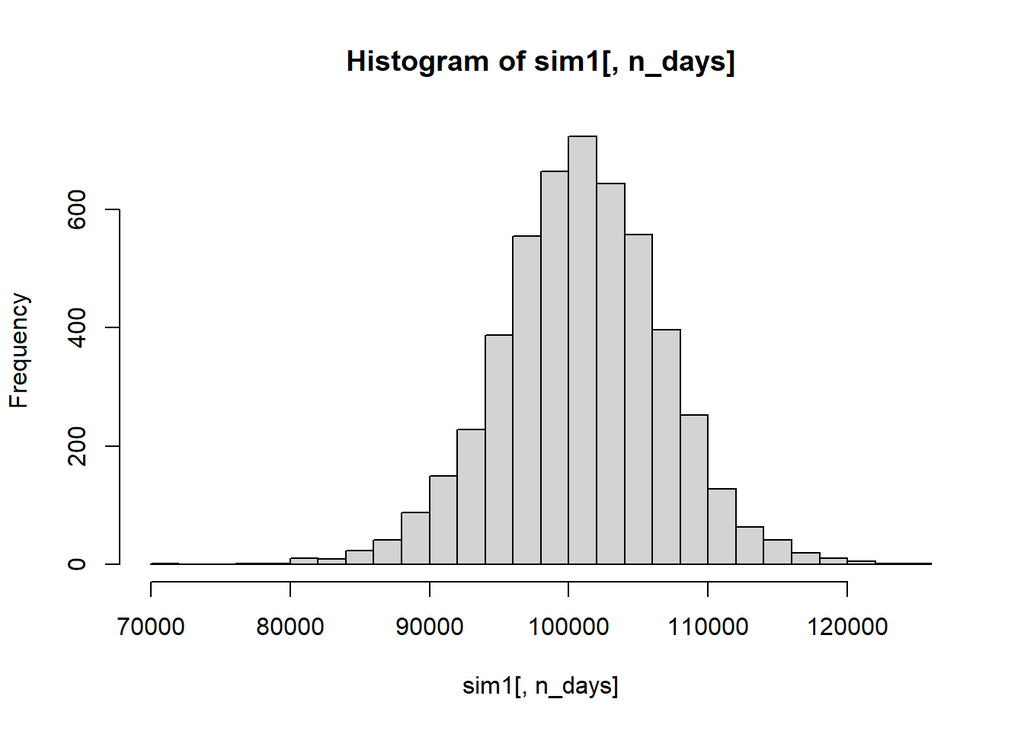

```r
hist(sim1[,n_days], 25)
```

```r
# Profit/loss
mean(sim1[,n_days])
```

```
## [1] 100913.6
```

```r
mean(sim1[,n_days] - initial_wealth)
```

```
## [1] 913.5547
```

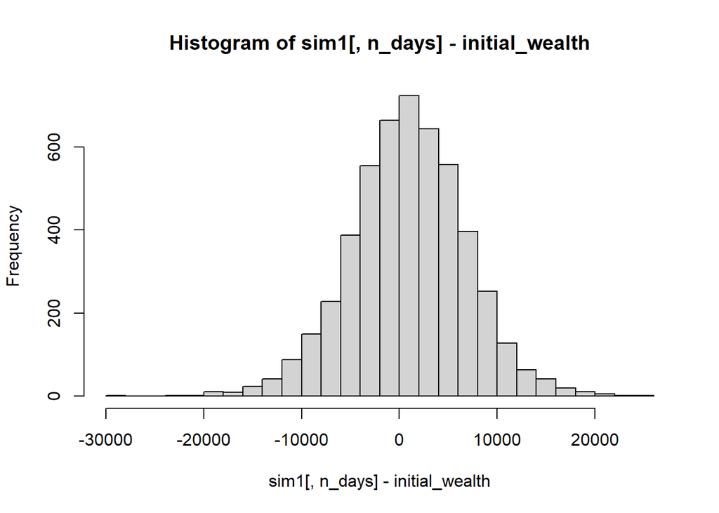

```r
hist(sim1[,n_days]- initial_wealth, breaks=30)
```

```r
# 5% value at risk:
quantile(sim1[,n_days]- initial_wealth, prob=0.05)
```

```
##        5%
## -8809.053
```

## Equal Investing

```r
return.today = resample(all_returns, 1, orig.ids=FALSE)

# Update the value of your holdings
# Assumes an equal allocation to each asset
total_wealth = 100000
my_weights = c(0.2,0.2,0.2, 0.2, 0.2)
holdings = total_wealth*my_weights
holdings = holdings*(1 + return.today)

# Compute your new total wealth
holdings
```

```
##            ClCl.SPYa ClCl.VOOa ClCl.QQQa ClCl.VNQa ClCl.ARKKa
## 2019-05-21  20180.31  20169.46  20208.95  20170.92    20451.9
```

```r
total_wealth = sum(holdings)
total_wealth
```

```
## [1] 101181.5
```

```r
## begin block
total_wealth = 100000
weights = c(0.2,0.2,0.2, 0.2, 0.2)
holdings = weights * total_wealth
n_days = 20  # capital T in the notes
wealthtracker = rep(0, n_days) # Set up a placeholder to track total wealth
for(today in 1:n_days) {
    return.today = resample(all_returns, 1, orig.ids=FALSE)  # sampling from R matrix in notes
    holdings = holdings + holdings*return.today
    total_wealth = sum(holdings)
    wealthtracker[today] = total_wealth
}
total_wealth
```

```
## [1] 99454.09
```

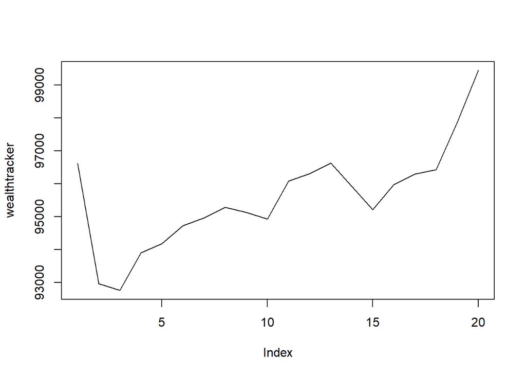

```r
plot(wealthtracker, type='l')
```

```r
## end block
```

```r
initial_wealth = 100000
sim1 = foreach(i=1:5000, .combine='rbind') %do% {
    total_wealth = initial_wealth
    weights = c(0.2,0.2,0.2,0.2,0.2)
    holdings = weights * total_wealth
    n_days = 20
    wealthtracker = rep(0, n_days)
    for(today in 1:n_days) {
        return.today = resample(all_returns, 1, orig.ids=FALSE)
        holdings = holdings + holdings*return.today
        total_wealth = sum(holdings)
        wealthtracker[today] = total_wealth
    }
    wealthtracker
}

# each row is a simulated trajectory
# each column is a data
head(sim1)
```

```
##               [,1]      [,2]      [,3]      [,4]      [,5]      [,6]      [,7]
## result.1  98826.09 102467.10 105548.62 104061.97 102300.01 100475.01  96762.86
## result.2  98698.11  98898.53  99062.18  97780.37  97737.31  97906.04  97482.57
## result.3 102443.30 103424.97 103817.01 104142.38 103938.89 104313.28 105040.40
## result.4 100297.14 102788.41 102555.51 103257.89 103273.26 105332.15 106273.81
## result.5 101361.11 101626.86 100426.06 100452.98  95213.57  93583.49  93953.06
## result.6  99318.73  99397.58 102418.78 104177.39 104502.55 104608.68 104520.95
##               [,8]      [,9]     [,10]     [,11]     [,12]     [,13]     [,14]
## result.1  94950.92  93851.43  94431.14  94609.86  91840.57  91763.01  89630.02
## result.2  98582.95  98368.31 100840.84 101257.92 101367.42 103939.06 103492.89
## result.3 105839.19 107534.82 106987.00 106750.99 107231.70 107102.42 105833.68
## result.4 106038.57 103545.63 103287.73 102074.95 100753.84  99771.92  98046.44
## result.5  93564.78  93851.77  94236.30  95326.96  96039.28  94915.70  94157.62
## result.6 103974.43 102778.14 100551.49 100632.05 101980.36 101571.14 101871.63
##              [,15]     [,16]     [,17]     [,18]     [,19]     [,20]
## result.1  90200.46  90194.53  90586.26  90238.57  91470.73  92128.18
## result.2 104712.67 106059.86 105357.92 105806.15 106284.20 106709.40
## result.3 105506.12 105228.27 104966.26 106319.18 106244.92 105515.86
## result.4  98348.88  96888.88  95059.42  95134.40  95279.22  94795.44
## result.5  93923.99  94627.79  94571.51  95241.08  95138.30  95940.80
## result.6 102352.36 101922.53 103673.38 102908.11 104382.28 104503.41
```

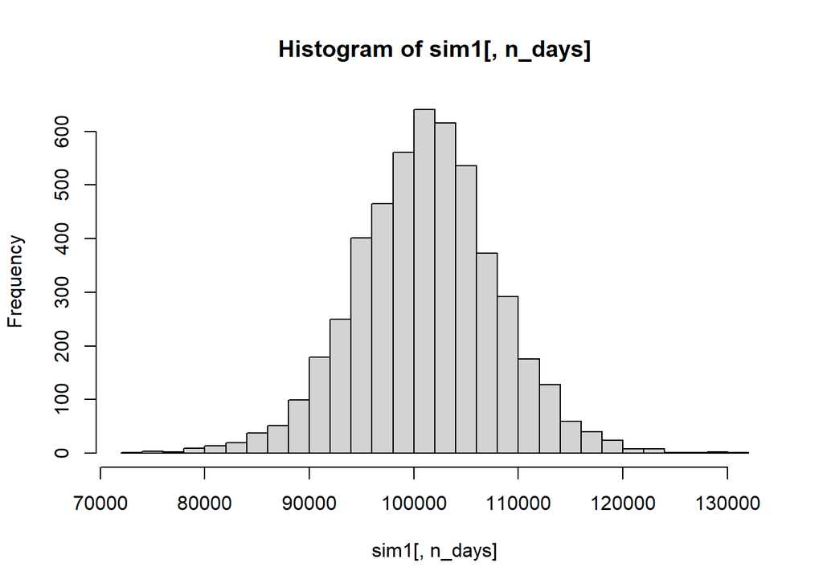

```r
hist(sim1[,n_days], 25)
```

```r
# Profit/loss
mean(sim1[,n_days])
```

```
## [1] 101172.1
```

```r
mean(sim1[,n_days] - initial_wealth)
```

```
## [1] 1172.069
```

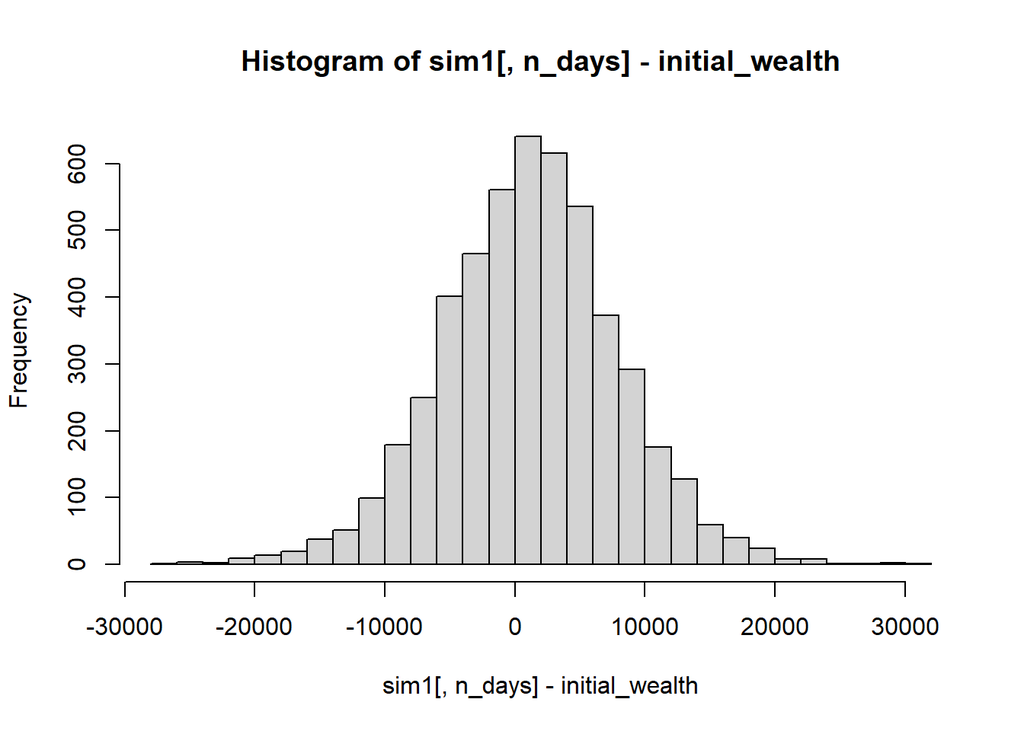

```r
hist(sim1[,n_days]- initial_wealth, breaks=30)
```

```r
# 5% value at risk:
quantile(sim1[,n_days]- initial_wealth, prob=0.05)
```

```
##        5%
## -9863.873
```

We expect to lose around $10,000 at the worst case scenario